# Risk Factor Analysis

## Outcome Variable

**Outcome Variable:** whz

## Predictor Variables

**Intervention Variable:** mwtkg

**Adjustment Set:**

- arm
- W_mage
- meducyrs
- feducyrs
- single
- brthmon
- W_parity
- delta_W_mage
- delta_meducyrs
- delta_feducyrs
- delta_single
- delta_brthmon
- delta_W_parity

## Stratifying Variables

The analysis was stratified on these variable(s):

- agecat
- studyid
- country

## Data Summary

| agecat | studyid | country | mwtkg | n_cell | n | outcome_variable |
| --- | --- | --- | --- | --- | --- | --- |
| Birth | ki0047075b-MAL-ED | BANGLADESH | >=58 kg | 37 | 209 | whz |
| Birth | ki0047075b-MAL-ED | BANGLADESH | <52 kg | 131 | 209 | whz |
| Birth | ki0047075b-MAL-ED | BANGLADESH | [52-58) kg | 41 | 209 | whz |
| Birth | ki0047075b-MAL-ED | BRAZIL | >=58 kg | 33 | 61 | whz |
| Birth | ki0047075b-MAL-ED | BRAZIL | <52 kg | 14 | 61 | whz |
| Birth | ki0047075b-MAL-ED | BRAZIL | [52-58) kg | 14 | 61 | whz |
| Birth | ki0047075b-MAL-ED | INDIA | >=58 kg | 6 | 41 | whz |
| Birth | ki0047075b-MAL-ED | INDIA | <52 kg | 28 | 41 | whz |
| Birth | ki0047075b-MAL-ED | INDIA | [52-58) kg | 7 | 41 | whz |
| Birth | ki0047075b-MAL-ED | NEPAL | >=58 kg | 9 | 26 | whz |
| Birth | ki0047075b-MAL-ED | NEPAL | <52 kg | 7 | 26 | whz |
| Birth | ki0047075b-MAL-ED | NEPAL | [52-58) kg | 10 | 26 | whz |
| Birth | ki0047075b-MAL-ED | PERU | >=58 kg | 82 | 221 | whz |
| Birth | ki0047075b-MAL-ED | PERU | <52 kg | 81 | 221 | whz |
| Birth | ki0047075b-MAL-ED | PERU | [52-58) kg | 58 | 221 | whz |
| Birth | ki0047075b-MAL-ED | SOUTH AFRICA | >=58 kg | 69 | 100 | whz |
| Birth | ki0047075b-MAL-ED | SOUTH AFRICA | <52 kg | 10 | 100 | whz |
| Birth | ki0047075b-MAL-ED | SOUTH AFRICA | [52-58) kg | 21 | 100 | whz |
| Birth | ki0047075b-MAL-ED | TANZANIA, UNITED REPUBLIC OF | >=58 kg | 44 | 113 | whz |
| Birth | ki0047075b-MAL-ED | TANZANIA, UNITED REPUBLIC OF | <52 kg | 40 | 113 | whz |
| Birth | ki0047075b-MAL-ED | TANZANIA, UNITED REPUBLIC OF | [52-58) kg | 29 | 113 | whz |
| Birth | ki1000304b-SAS-CompFeed | INDIA | >=58 kg | 89 | 1091 | whz |
| Birth | ki1000304b-SAS-CompFeed | INDIA | <52 kg | 824 | 1091 | whz |
| Birth | ki1000304b-SAS-CompFeed | INDIA | [52-58) kg | 178 | 1091 | whz |
| Birth | ki1017093-NIH-Birth | BANGLADESH | >=58 kg | 79 | 575 | whz |
| Birth | ki1017093-NIH-Birth | BANGLADESH | <52 kg | 414 | 575 | whz |
| Birth | ki1017093-NIH-Birth | BANGLADESH | [52-58) kg | 82 | 575 | whz |
| Birth | ki1017093b-PROVIDE | BANGLADESH | >=58 kg | 89 | 510 | whz |
| Birth | ki1017093b-PROVIDE | BANGLADESH | <52 kg | 326 | 510 | whz |
| Birth | ki1017093b-PROVIDE | BANGLADESH | [52-58) kg | 95 | 510 | whz |

[output cut: 105 more lines]

The following strata were considered:

- agecat: 24 months, studyid: ki0047075b-MAL-ED, country: BANGLADESH
- agecat: 24 months, studyid: ki0047075b-MAL-ED, country: BRAZIL
- agecat: 24 months, studyid: ki0047075b-MAL-ED, country: INDIA
- agecat: 24 months, studyid: ki0047075b-MAL-ED, country: NEPAL
- agecat: 24 months, studyid: ki0047075b-MAL-ED, country: PERU
- agecat: 24 months, studyid: ki0047075b-MAL-ED, country: SOUTH AFRICA
- agecat: 24 months, studyid: ki0047075b-MAL-ED, country: TANZANIA, UNITED REPUBLIC OF
- agecat: 24 months, studyid: ki1017093-NIH-Birth, country: BANGLADESH
- agecat: 24 months, studyid: ki1017093b-PROVIDE, country: BANGLADESH
- agecat: 24 months, studyid: ki1017093c-NIH-Crypto, country: BANGLADESH
- agecat: 24 months, studyid: ki1066203-TanzaniaChild2, country: TANZANIA, UNITED REPUBLIC OF
- agecat: 24 months, studyid: ki1119695-PROBIT, country: BELARUS
- agecat: 24 months, studyid: ki1126311-ZVITAMBO, country: ZIMBABWE
- agecat: 24 months, studyid: ki1148112-LCNI-5, country: MALAWI
- agecat: 24 months, studyid: kiGH5241-JiVitA-3, country: BANGLADESH
- agecat: 6 months, studyid: ki0047075b-MAL-ED, country: BANGLADESH
- agecat: 6 months, studyid: ki0047075b-MAL-ED, country: BRAZIL
- agecat: 6 months, studyid: ki0047075b-MAL-ED, country: INDIA
- agecat: 6 months, studyid: ki0047075b-MAL-ED, country: NEPAL
- agecat: 6 months, studyid: ki0047075b-MAL-ED, country: PERU
- agecat: 6 months, studyid: ki0047075b-MAL-ED, country: SOUTH AFRICA
- agecat: 6 months, studyid: ki0047075b-MAL-ED, country: TANZANIA, UNITED REPUBLIC OF
- agecat: 6 months, studyid: ki1000304b-SAS-CompFeed, country: INDIA
- agecat: 6 months, studyid: ki1017093-NIH-Birth, country: BANGLADESH
- agecat: 6 months, studyid: ki1017093b-PROVIDE, country: BANGLADESH
- agecat: 6 months, studyid: ki1017093c-NIH-Crypto, country: BANGLADESH
- agecat: 6 months, studyid: ki1066203-TanzaniaChild2, country: TANZANIA, UNITED REPUBLIC OF
- agecat: 6 months, studyid: ki1119695-PROBIT, country: BELARUS
- agecat: 6 months, studyid: ki1126311-ZVITAMBO, country: ZIMBABWE
- agecat: 6 months, studyid: ki1148112-LCNI-5, country: MALAWI
- agecat: 6 months, studyid: kiGH5241-JiVitA-3, country: BANGLADESH
- agecat: Birth, studyid: ki0047075b-MAL-ED, country: BANGLADESH
- agecat: Birth, studyid: ki0047075b-MAL-ED, country: BRAZIL
- agecat: Birth, studyid: ki0047075b-MAL-ED, country: INDIA
- agecat: Birth, studyid: ki0047075b-MAL-ED, country: NEPAL
- agecat: Birth, studyid: ki0047075b-MAL-ED, country: PERU
- agecat: Birth, studyid: ki0047075b-MAL-ED, country: SOUTH AFRICA
- agecat: Birth, studyid: ki0047075b-MAL-ED, country: TANZANIA, UNITED REPUBLIC OF
- agecat: Birth, studyid: ki1000304b-SAS-CompFeed, country: INDIA
- agecat: Birth, studyid: ki1017093-NIH-Birth, country: BANGLADESH
- agecat: Birth, studyid: ki1017093b-PROVIDE, country: BANGLADESH
- agecat: Birth, studyid: ki1017093c-NIH-Crypto, country: BANGLADESH
- agecat: Birth, studyid: ki1119695-PROBIT, country: BELARUS
- agecat: Birth, studyid: ki1126311-ZVITAMBO, country: ZIMBABWE
- agecat: Birth, studyid: kiGH5241-JiVitA-3, country: BANGLADESH

### Dropped Strata

Some strata were dropped due to rare outcomes:

- agecat: 24 months, studyid: ki1066203-TanzaniaChild2, country: TANZANIA, UNITED REPUBLIC OF

## Methods Detail

We’re interested in the causal parameters $E[Y_a]$ for all values of $a \in \mathcal{A}$. These parameters represent the mean outcome if, possibly contrary to fact, we intervened to set all units to have $A=a$. Under the randomization and positivity assumptions, these are identified by the statistical parameters $\psi_a=E_W[E_{Y|A,W}(Y|A=a,W)]$. In addition, we’re interested in the mean of $Y$, $E[Y]$ under no intervention (the observed mean). We will estimate these parameters by using SuperLearner to fit the relevant likelihood factors – $E_{Y|A,W}(Y|A=a,W)$ and $p(A=a|W)$, and then updating our likelihood fit using a joint TMLE.

For unadjusted analyses ($W=\{\}$), initial likelihoods were estimated using Lrnr_glm to estimate the simple $E(Y|A)$ and Lrnr_mean to estimate $p(A)$. For adjusted analyses, a small library containing Lrnr_glmnet, Lrnr_xgboost, and Lrnr_mean was used.

Having estimated these parameters, we will then use the delta method to estimate relative risks and attributable risks relative to a prespecified baseline level of $A$.

# Results Detail

## Results Plots

[figure not shown]

[figure not shown]

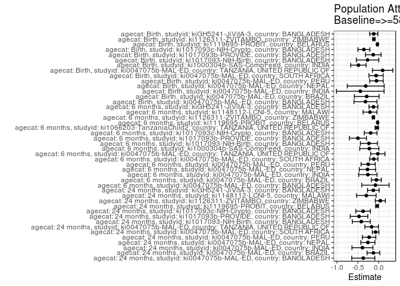

## Results Table

### Parameter: TSM

| agecat | studyid | country | intervention_level | baseline_level | estimate | ci_lower | ci_upper |
| --- | --- | --- | --- | --- | --- | --- | --- |
| Birth | ki0047075b-MAL-ED | BANGLADESH | >=58 kg | NA | -0.6367414 | -0.9233556 | -0.3501273 |
| Birth | ki0047075b-MAL-ED | BANGLADESH | <52 kg | NA | -1.0066419 | -1.1987095 | -0.8145744 |
| Birth | ki0047075b-MAL-ED | BANGLADESH | [52-58) kg | NA | -1.0176367 | -1.3692824 | -0.6659909 |
| Birth | ki0047075b-MAL-ED | BRAZIL | >=58 kg | NA | 0.6886660 | 0.3139995 | 1.0633325 |
| Birth | ki0047075b-MAL-ED | BRAZIL | <52 kg | NA | 0.1456823 | -0.7203906 | 1.0117553 |
| Birth | ki0047075b-MAL-ED | BRAZIL | [52-58) kg | NA | -0.0133852 | -0.7736638 | 0.7468934 |
| Birth | ki0047075b-MAL-ED | INDIA | >=58 kg | NA | -0.5266667 | -1.1151354 | 0.0618020 |
| Birth | ki0047075b-MAL-ED | INDIA | <52 kg | NA | -1.0517857 | -1.4197431 | -0.6838283 |
| Birth | ki0047075b-MAL-ED | INDIA | [52-58) kg | NA | -1.0100000 | -1.5034877 | -0.5165123 |
| Birth | ki0047075b-MAL-ED | NEPAL | >=58 kg | NA | -0.4577778 | -0.9265727 | 0.0110172 |
| Birth | ki0047075b-MAL-ED | NEPAL | <52 kg | NA | -0.8900000 | -1.4411585 | -0.3388415 |
| Birth | ki0047075b-MAL-ED | NEPAL | [52-58) kg | NA | -0.9630000 | -1.6574487 | -0.2685513 |
| Birth | ki0047075b-MAL-ED | PERU | >=58 kg | NA | 0.0100776 | -0.1871165 | 0.2072718 |
| Birth | ki0047075b-MAL-ED | PERU | <52 kg | NA | -0.1678026 | -0.3662131 | 0.0306079 |
| Birth | ki0047075b-MAL-ED | PERU | [52-58) kg | NA | 0.1066045 | -0.1502456 | 0.3634547 |
| Birth | ki0047075b-MAL-ED | SOUTH AFRICA | >=58 kg | NA | -0.1299631 | -0.4088484 | 0.1489221 |
| Birth | ki0047075b-MAL-ED | SOUTH AFRICA | <52 kg | NA | -0.1099366 | -0.7376842 | 0.5178109 |
| Birth | ki0047075b-MAL-ED | SOUTH AFRICA | [52-58) kg | NA | -0.2655697 | -0.9388835 | 0.4077441 |
| Birth | ki0047075b-MAL-ED | TANZANIA, UNITED REPUBLIC OF | >=58 kg | NA | 0.6640880 | 0.3576092 | 0.9705668 |
| Birth | ki0047075b-MAL-ED | TANZANIA, UNITED REPUBLIC OF | <52 kg | NA | 0.7943525 | 0.4674847 | 1.1212202 |
| Birth | ki0047075b-MAL-ED | TANZANIA, UNITED REPUBLIC OF | [52-58) kg | NA | 0.7337189 | 0.3193071 | 1.1481306 |
| Birth | ki1000304b-SAS-CompFeed | INDIA | >=58 kg | NA | -0.1804183 | -0.4755307 | 0.1146940 |
| Birth | ki1000304b-SAS-CompFeed | INDIA | <52 kg | NA | -0.7343983 | -0.8848472 | -0.5839493 |
| Birth | ki1000304b-SAS-CompFeed | INDIA | [52-58) kg | NA | -0.5764765 | -0.8214206 | -0.3315324 |
| Birth | ki1017093-NIH-Birth | BANGLADESH | >=58 kg | NA | -1.0838448 | -1.3731328 | -0.7945568 |
| Birth | ki1017093-NIH-Birth | BANGLADESH | <52 kg | NA | -1.4010750 | -1.5107724 | -1.2913776 |
| Birth | ki1017093-NIH-Birth | BANGLADESH | [52-58) kg | NA | -1.2473597 | -1.5402829 | -0.9544366 |
| Birth | ki1017093b-PROVIDE | BANGLADESH | >=58 kg | NA | -1.1758634 | -1.3844918 | -0.9672350 |
| Birth | ki1017093b-PROVIDE | BANGLADESH | <52 kg | NA | -1.3447526 | -1.4423709 | -1.2471343 |
| Birth | ki1017093b-PROVIDE | BANGLADESH | [52-58) kg | NA | -1.2676229 | -1.4472809 | -1.0879649 |

[output cut: 102 more lines]

### Parameter: E(Y)

| agecat | studyid | country | intervention_level | baseline_level | estimate | ci_lower | ci_upper |
| --- | --- | --- | --- | --- | --- | --- | --- |
| Birth | ki0047075b-MAL-ED | BANGLADESH | NA | NA | -0.9533493 | -1.0984355 | -0.8082631 |
| Birth | ki0047075b-MAL-ED | BRAZIL | NA | NA | 0.4018033 | 0.0834093 | 0.7201973 |
| Birth | ki0047075b-MAL-ED | INDIA | NA | NA | -0.9678049 | -1.2522118 | -0.6833979 |
| Birth | ki0047075b-MAL-ED | NEPAL | NA | NA | -0.7684615 | -1.1257770 | -0.4111460 |
| Birth | ki0047075b-MAL-ED | PERU | NA | NA | -0.0429864 | -0.1658406 | 0.0798678 |
| Birth | ki0047075b-MAL-ED | SOUTH AFRICA | NA | NA | -0.1930000 | -0.4278634 | 0.0418634 |
| Birth | ki0047075b-MAL-ED | TANZANIA, UNITED REPUBLIC OF | NA | NA | 0.7583186 | 0.5636385 | 0.9529987 |
| Birth | ki1000304b-SAS-CompFeed | INDIA | NA | NA | -0.6660770 | -0.8389738 | -0.4931801 |
| Birth | ki1017093-NIH-Birth | BANGLADESH | NA | NA | -1.3499217 | -1.4444634 | -1.2553801 |
| Birth | ki1017093b-PROVIDE | BANGLADESH | NA | NA | -1.3060980 | -1.3843247 | -1.2278714 |
| Birth | ki1017093c-NIH-Crypto | BANGLADESH | NA | NA | -1.2434730 | -1.3276901 | -1.1592559 |
| Birth | ki1119695-PROBIT | BELARUS | NA | NA | -1.1429853 | -1.3532634 | -0.9327073 |
| Birth | ki1126311-ZVITAMBO | ZIMBABWE | NA | NA | -0.4824198 | -0.5113303 | -0.4535093 |
| Birth | kiGH5241-JiVitA-3 | BANGLADESH | NA | NA | -0.7780622 | -0.7970926 | -0.7590319 |
| 6 months | ki0047075b-MAL-ED | BANGLADESH | NA | NA | -0.1376763 | -0.2664642 | -0.0088885 |
| 6 months | ki0047075b-MAL-ED | BRAZIL | NA | NA | 0.9648518 | 0.8004118 | 1.1292917 |
| 6 months | ki0047075b-MAL-ED | INDIA | NA | NA | -0.7034149 | -0.8300527 | -0.5767771 |
| 6 months | ki0047075b-MAL-ED | NEPAL | NA | NA | 0.1104308 | -0.0208643 | 0.2417259 |
| 6 months | ki0047075b-MAL-ED | PERU | NA | NA | 1.0548591 | 0.9328922 | 1.1768259 |
| 6 months | ki0047075b-MAL-ED | SOUTH AFRICA | NA | NA | 0.5291499 | 0.3751396 | 0.6831602 |
| 6 months | ki0047075b-MAL-ED | TANZANIA, UNITED REPUBLIC OF | NA | NA | 0.5362213 | 0.4049390 | 0.6675036 |
| 6 months | ki1000304b-SAS-CompFeed | INDIA | NA | NA | -0.6660835 | -0.8034722 | -0.5286949 |
| 6 months | ki1017093-NIH-Birth | BANGLADESH | NA | NA | -0.4474038 | -0.5378167 | -0.3569909 |
| 6 months | ki1017093b-PROVIDE | BANGLADESH | NA | NA | -0.1987071 | -0.2815473 | -0.1158669 |
| 6 months | ki1017093c-NIH-Crypto | BANGLADESH | NA | NA | 0.0297622 | -0.0491685 | 0.1086930 |
| 6 months | ki1066203-TanzaniaChild2 | TANZANIA, UNITED REPUBLIC OF | NA | NA | 0.0780261 | 0.0247830 | 0.1312691 |
| 6 months | ki1119695-PROBIT | BELARUS | NA | NA | 0.5834072 | 0.5254491 | 0.6413653 |
| 6 months | ki1126311-ZVITAMBO | ZIMBABWE | NA | NA | 0.2987004 | 0.2725093 | 0.3248915 |
| 6 months | ki1148112-LCNI-5 | MALAWI | NA | NA | 0.4518519 | 0.3806435 | 0.5230602 |
| 6 months | kiGH5241-JiVitA-3 | BANGLADESH | NA | NA | -0.5934435 | -0.6129939 | -0.5738931 |
| 24 months | ki0047075b-MAL-ED | BANGLADESH | NA | NA | -0.8192925 | -0.9412667 | -0.6973182 |
| 24 months | ki0047075b-MAL-ED | BRAZIL | NA | NA | 0.4443651 | 0.2404149 | 0.6483153 |
| 24 months | ki0047075b-MAL-ED | INDIA | NA | NA | -0.9519248 | -1.0678488 | -0.8360007 |
| 24 months | ki0047075b-MAL-ED | NEPAL | NA | NA | -0.3749123 | -0.4886073 | -0.2612173 |
| 24 months | ki0047075b-MAL-ED | PERU | NA | NA | 0.1111982 | -0.0118399 | 0.2342362 |
| 24 months | ki0047075b-MAL-ED | SOUTH AFRICA | NA | NA | 0.3916417 | 0.2704414 | 0.5128421 |
| 24 months | ki0047075b-MAL-ED | TANZANIA, UNITED REPUBLIC OF | NA | NA | 0.0547975 | -0.0703378 | 0.1799328 |
| 24 months | ki1017093-NIH-Birth | BANGLADESH | NA | NA | -0.9115790 | -1.0095022 | -0.8136559 |
| 24 months | ki1017093b-PROVIDE | BANGLADESH | NA | NA | -0.8914360 | -0.9741797 | -0.8086923 |
| 24 months | ki1017093c-NIH-Crypto | BANGLADESH | NA | NA | -0.6103502 | -0.7050157 | -0.5156847 |
| 24 months | ki1119695-PROBIT | BELARUS | NA | NA | 0.6888304 | 0.5749159 | 0.8027449 |
| 24 months | ki1126311-ZVITAMBO | ZIMBABWE | NA | NA | -1.1835154 | -1.2835950 | -1.0834359 |
| 24 months | ki1148112-LCNI-5 | MALAWI | NA | NA | -0.0466281 | -0.1286250 | 0.0353688 |
| 24 months | kiGH5241-JiVitA-3 | BANGLADESH | NA | NA | -1.2974564 | -1.3207535 | -1.2741592 |

### Parameter: ATE

| agecat | studyid | country | intervention_level | baseline_level | estimate | ci_lower | ci_upper |
| --- | --- | --- | --- | --- | --- | --- | --- |
| Birth | ki0047075b-MAL-ED | BANGLADESH | >=58 kg | >=58 kg | 0.0000000 | 0.0000000 | 0.0000000 |
| Birth | ki0047075b-MAL-ED | BANGLADESH | <52 kg | >=58 kg | -0.3699005 | -0.7158638 | -0.0239373 |
| Birth | ki0047075b-MAL-ED | BANGLADESH | [52-58) kg | >=58 kg | -0.3808952 | -0.8348530 | 0.0730626 |
| Birth | ki0047075b-MAL-ED | BRAZIL | >=58 kg | >=58 kg | 0.0000000 | 0.0000000 | 0.0000000 |
| Birth | ki0047075b-MAL-ED | BRAZIL | <52 kg | >=58 kg | -0.5429837 | -1.4921062 | 0.4061388 |
| Birth | ki0047075b-MAL-ED | BRAZIL | [52-58) kg | >=58 kg | -0.7020513 | -1.5516328 | 0.1475303 |
| Birth | ki0047075b-MAL-ED | INDIA | >=58 kg | >=58 kg | 0.0000000 | 0.0000000 | 0.0000000 |
| Birth | ki0047075b-MAL-ED | INDIA | <52 kg | >=58 kg | -0.5251190 | -1.2191566 | 0.1689185 |
| Birth | ki0047075b-MAL-ED | INDIA | [52-58) kg | >=58 kg | -0.4833333 | -1.2513343 | 0.2846676 |
| Birth | ki0047075b-MAL-ED | NEPAL | >=58 kg | >=58 kg | 0.0000000 | 0.0000000 | 0.0000000 |
| Birth | ki0047075b-MAL-ED | NEPAL | <52 kg | >=58 kg | -0.4322222 | -1.1557859 | 0.2913414 |
| Birth | ki0047075b-MAL-ED | NEPAL | [52-58) kg | >=58 kg | -0.5052222 | -1.3430932 | 0.3326487 |
| Birth | ki0047075b-MAL-ED | PERU | >=58 kg | >=58 kg | 0.0000000 | 0.0000000 | 0.0000000 |
| Birth | ki0047075b-MAL-ED | PERU | <52 kg | >=58 kg | -0.1778802 | -0.4593689 | 0.1036085 |
| Birth | ki0047075b-MAL-ED | PERU | [52-58) kg | >=58 kg | 0.0965269 | -0.2279055 | 0.4209592 |
| Birth | ki0047075b-MAL-ED | SOUTH AFRICA | >=58 kg | >=58 kg | 0.0000000 | 0.0000000 | 0.0000000 |
| Birth | ki0047075b-MAL-ED | SOUTH AFRICA | <52 kg | >=58 kg | 0.0200265 | -0.6613561 | 0.7014091 |
| Birth | ki0047075b-MAL-ED | SOUTH AFRICA | [52-58) kg | >=58 kg | -0.1356066 | -0.8631245 | 0.5919114 |
| Birth | ki0047075b-MAL-ED | TANZANIA, UNITED REPUBLIC OF | >=58 kg | >=58 kg | 0.0000000 | 0.0000000 | 0.0000000 |
| Birth | ki0047075b-MAL-ED | TANZANIA, UNITED REPUBLIC OF | <52 kg | >=58 kg | 0.1302645 | -0.3205017 | 0.5810307 |
| Birth | ki0047075b-MAL-ED | TANZANIA, UNITED REPUBLIC OF | [52-58) kg | >=58 kg | 0.0696309 | -0.4459031 | 0.5851649 |
| Birth | ki1000304b-SAS-CompFeed | INDIA | >=58 kg | >=58 kg | 0.0000000 | 0.0000000 | 0.0000000 |
| Birth | ki1000304b-SAS-CompFeed | INDIA | <52 kg | >=58 kg | -0.5539799 | -0.7745708 | -0.3333890 |
| Birth | ki1000304b-SAS-CompFeed | INDIA | [52-58) kg | >=58 kg | -0.3960582 | -0.5648231 | -0.2272933 |
| Birth | ki1017093-NIH-Birth | BANGLADESH | >=58 kg | >=58 kg | 0.0000000 | 0.0000000 | 0.0000000 |
| Birth | ki1017093-NIH-Birth | BANGLADESH | <52 kg | >=58 kg | -0.3172302 | -0.6257701 | -0.0086903 |
| Birth | ki1017093-NIH-Birth | BANGLADESH | [52-58) kg | >=58 kg | -0.1635150 | -0.5750731 | 0.2480432 |
| Birth | ki1017093b-PROVIDE | BANGLADESH | >=58 kg | >=58 kg | 0.0000000 | 0.0000000 | 0.0000000 |
| Birth | ki1017093b-PROVIDE | BANGLADESH | <52 kg | >=58 kg | -0.1688892 | -0.3992567 | 0.0614783 |
| Birth | ki1017093b-PROVIDE | BANGLADESH | [52-58) kg | >=58 kg | -0.0917595 | -0.3670349 | 0.1835159 |

[output cut: 102 more lines]

### Parameter: PAR

| agecat | studyid | country | intervention_level | baseline_level | estimate | ci_lower | ci_upper |
| --- | --- | --- | --- | --- | --- | --- | --- |
| Birth | ki0047075b-MAL-ED | BANGLADESH | >=58 kg | NA | -0.3166078 | -0.5927797 | -0.0404360 |
| Birth | ki0047075b-MAL-ED | BRAZIL | >=58 kg | NA | -0.2868628 | -0.5828884 | 0.0091629 |
| Birth | ki0047075b-MAL-ED | INDIA | >=58 kg | NA | -0.4411382 | -1.0119516 | 0.1296752 |
| Birth | ki0047075b-MAL-ED | NEPAL | >=58 kg | NA | -0.3106838 | -0.7526063 | 0.1312387 |
| Birth | ki0047075b-MAL-ED | PERU | >=58 kg | NA | -0.0530641 | -0.2154461 | 0.1093180 |
| Birth | ki0047075b-MAL-ED | SOUTH AFRICA | >=58 kg | NA | -0.0630369 | -0.2330955 | 0.1070218 |
| Birth | ki0047075b-MAL-ED | TANZANIA, UNITED REPUBLIC OF | >=58 kg | NA | 0.0942306 | -0.1503237 | 0.3387849 |
| Birth | ki1000304b-SAS-CompFeed | INDIA | >=58 kg | NA | -0.4856587 | -0.6702573 | -0.3010600 |
| Birth | ki1017093-NIH-Birth | BANGLADESH | >=58 kg | NA | -0.2660770 | -0.5355711 | 0.0034172 |
| Birth | ki1017093b-PROVIDE | BANGLADESH | >=58 kg | NA | -0.1302346 | -0.3181917 | 0.0577224 |
| Birth | ki1017093c-NIH-Crypto | BANGLADESH | >=58 kg | NA | -0.3546906 | -0.4977879 | -0.2115932 |
| Birth | ki1119695-PROBIT | BELARUS | >=58 kg | NA | -0.0306853 | -0.0468327 | -0.0145380 |
| Birth | ki1126311-ZVITAMBO | ZIMBABWE | >=58 kg | NA | -0.1148899 | -0.1425491 | -0.0872307 |
| Birth | kiGH5241-JiVitA-3 | BANGLADESH | >=58 kg | NA | -0.1176228 | -0.2150207 | -0.0202248 |
| 6 months | ki0047075b-MAL-ED | BANGLADESH | >=58 kg | NA | -0.0784893 | -0.4069991 | 0.2500205 |
| 6 months | ki0047075b-MAL-ED | BRAZIL | >=58 kg | NA | -0.0558532 | -0.1738001 | 0.0620937 |
| 6 months | ki0047075b-MAL-ED | INDIA | >=58 kg | NA | -0.2597314 | -0.4791471 | -0.0403158 |
| 6 months | ki0047075b-MAL-ED | NEPAL | >=58 kg | NA | -0.2690394 | -0.4642790 | -0.0737998 |
| 6 months | ki0047075b-MAL-ED | PERU | >=58 kg | NA | -0.2520923 | -0.4221928 | -0.0819917 |
| 6 months | ki0047075b-MAL-ED | SOUTH AFRICA | >=58 kg | NA | -0.1179925 | -0.2179244 | -0.0180606 |
| 6 months | ki0047075b-MAL-ED | TANZANIA, UNITED REPUBLIC OF | >=58 kg | NA | -0.0211328 | -0.1920684 | 0.1498028 |
| 6 months | ki1000304b-SAS-CompFeed | INDIA | >=58 kg | NA | -0.2245122 | -0.4538039 | 0.0047795 |
| 6 months | ki1017093-NIH-Birth | BANGLADESH | >=58 kg | NA | -0.2344473 | -0.4388815 | -0.0300131 |
| 6 months | ki1017093b-PROVIDE | BANGLADESH | >=58 kg | NA | -0.4978221 | -0.7015851 | -0.2940591 |
| 6 months | ki1017093c-NIH-Crypto | BANGLADESH | >=58 kg | NA | -0.1932150 | -0.3456812 | -0.0407487 |
| 6 months | ki1066203-TanzaniaChild2 | TANZANIA, UNITED REPUBLIC OF | >=58 kg | NA | -0.0448066 | -0.0861119 | -0.0035012 |
| 6 months | ki1119695-PROBIT | BELARUS | >=58 kg | NA | -0.0254884 | -0.0372259 | -0.0137509 |
| 6 months | ki1126311-ZVITAMBO | ZIMBABWE | >=58 kg | NA | -0.1273832 | -0.1528061 | -0.1019602 |
| 6 months | ki1148112-LCNI-5 | MALAWI | >=58 kg | NA | -0.2083432 | -0.3747780 | -0.0419084 |
| 6 months | kiGH5241-JiVitA-3 | BANGLADESH | >=58 kg | NA | -0.1266395 | -0.2319540 | -0.0213251 |
| 24 months | ki0047075b-MAL-ED | BANGLADESH | >=58 kg | NA | -0.3691320 | -0.6458507 | -0.0924132 |
| 24 months | ki0047075b-MAL-ED | BRAZIL | >=58 kg | NA | -0.1264334 | -0.2792315 | 0.0263648 |
| 24 months | ki0047075b-MAL-ED | INDIA | >=58 kg | NA | -0.3891187 | -0.6404262 | -0.1378112 |
| 24 months | ki0047075b-MAL-ED | NEPAL | >=58 kg | NA | -0.2582364 | -0.4269198 | -0.0895531 |
| 24 months | ki0047075b-MAL-ED | PERU | >=58 kg | NA | -0.2295154 | -0.3908173 | -0.0682135 |
| 24 months | ki0047075b-MAL-ED | SOUTH AFRICA | >=58 kg | NA | -0.0737219 | -0.1527614 | 0.0053175 |
| 24 months | ki0047075b-MAL-ED | TANZANIA, UNITED REPUBLIC OF | >=58 kg | NA | -0.1694770 | -0.3314298 | -0.0075242 |
| 24 months | ki1017093-NIH-Birth | BANGLADESH | >=58 kg | NA | -0.4172757 | -0.6332249 | -0.2013264 |
| 24 months | ki1017093b-PROVIDE | BANGLADESH | >=58 kg | NA | -0.4719196 | -0.6823275 | -0.2615116 |
| 24 months | ki1017093c-NIH-Crypto | BANGLADESH | >=58 kg | NA | -0.3736478 | -0.5482964 | -0.1989992 |
| 24 months | ki1119695-PROBIT | BELARUS | >=58 kg | NA | -0.0388662 | -0.0719562 | -0.0057763 |
| 24 months | ki1126311-ZVITAMBO | ZIMBABWE | >=58 kg | NA | 0.0392848 | -0.0817902 | 0.1603598 |
| 24 months | ki1148112-LCNI-5 | MALAWI | >=58 kg | NA | -0.2961427 | -0.5299644 | -0.0623210 |
| 24 months | kiGH5241-JiVitA-3 | BANGLADESH | >=58 kg | NA | -0.1285786 | -0.2679689 | 0.0108116 |